# Unsupervised learning - clustering and dimension reduction

Anna Yeaton

Fall 2019

# Lab Section

Download auto data from the *Statistical Learning* book website here: http://www-bcf.usc.edu/~gareth/ISL/data.html

Today, we are going over Hierarchical clustering, K-Means Clustering, PCA, and ICA.

```r
# read in Auto data
Auto_data <- read_csv("Auto.csv")
#remove cars with unknown horsepower and set horsepower to numeric
Auto_data <- Auto_data %>%
  filter(horsepower != "?") %>%
  mutate(horsepower = as.numeric(horsepower)) %>%
  as.data.frame()

#save car names
Auto_data_names <- Auto_data$name

#data to cluster
Auto_data_clust <- Auto_data[,1:8]
dim(Auto_data_clust)
```

```
## [1] 392   8
```

```r
#392 is too much for a demo, so lets take the first 25
Auto_data_clust <- Auto_data_clust[1:25,]
rownames(Auto_data_clust) <- Auto_data_names[1:25]
```

## Hierarchical agglomerative clustering

Step 1. Assign each item to it’s own cluster. We start with 25 clusters, one for each car.

Step 2. Calculate a proximity matrix between each cluster.

Step 3. Find the pair of clusters closest to each other.

Step 4. Merge these clusters and then recalculate similarity between clusters. Some options are: single linkage (distance is calculated from the nearest neighbors), complete linkage (distance is calculated from furthest neighbor), average linkage (distance is calculated from mean of different clusters).

Step 5. Repeat Step 3 and 4 until there is only one cluster.

### In practice

Step 1. Each car is a cluster.

Step 2. Create a distance matrix from Auto_data_clust.

```r
help("dist")
```

```
## starting httpd help server ... done
```

```r
hierarchical_dist <- as.matrix(dist(Auto_data_clust, method = "euclidean"))
#View(hierarchical_dist)
```

Step 3. Find the two cars that are the most similar to each other and print the names of those two cars

```r
diag(hierarchical_dist) <- NA
arrayInd(which.min(hierarchical_dist), dim(hierarchical_dist))
```

```
##      [,1] [,2]
## [1,]   23   15
```

```r
#postitions 23 and 15 are the most similar. Lets go back to the names of the cars
Auto_data_names[23]
```

```
## [1] "saab 99e"
```

```r
Auto_data_names[15]
```

```
## [1] "toyota corona mark ii"
```

Step 4. Merge the two clusters together using average linkage.

```r
#replace pos 15 with the average of pos 15 and 23
hierarchical_dist[,15] <- apply((hierarchical_dist[,c(23,15)]),1,mean)
hierarchical_dist[15,] <- apply((hierarchical_dist[c(23,15),]),2,mean)

#remove pos 23
hierarchical_dist <- hierarchical_dist[-23,-23]

#now position 15 represents the cluster containing the saab99e and the toyota corona mark ii
```

Step 5. To complete the algorithm, go back to step 3 and iterate through all of the previous steps until there are no more rows left

```r
diag(hierarchical_dist) <- NA
arrayInd(which.min(hierarchical_dist), dim(hierarchical_dist))
```

```
##      [,1] [,2]
## [1,]    4    3
```

```r
#postitions 4 and 3 are the most similar
Auto_data_names[4]
```

```
## [1] "amc rebel sst"
```

```r
Auto_data_names[3]
```

```
## [1] "plymouth satellite"
```

### R function

Now that we know how the algorithm works, let’s use the R function hclust. Plot the Dendogram resulting from clustering the Auto_data_clust using average linkage.

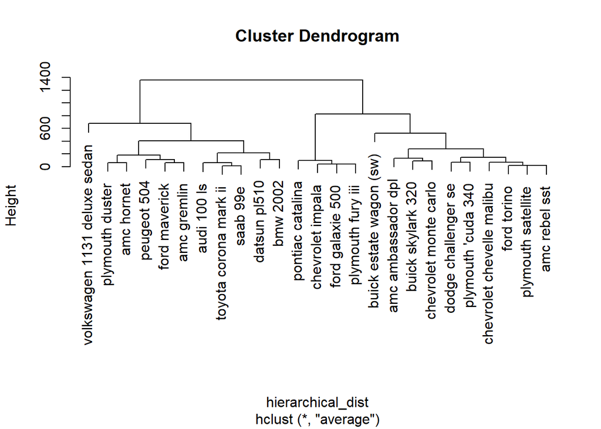

```r
hierarchical_dist <- dist(Auto_data_clust, method = "euclidean")
tree <- hclust(hierarchical_dist, method="average")
plot(tree)
```

There is one more element to hierarchical clustering: Cutting the tree. Here, we can control how many clusters we want or the height of the tree.

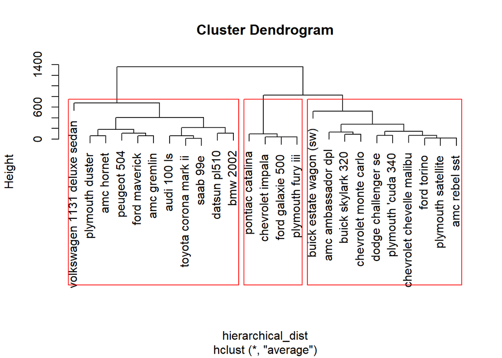

```r
#help(cutree)

# cut tree into 3 clusters
tree <- hclust(hierarchical_dist, method="average")
plot(tree)
tree_k2 <- cutree(tree, k = 2)
# plot the tree before running this line
rect.hclust(tree, k = 3, h = NULL)
```

## Principal Components Analysis (PCA)

Principal Components Analysis is a linear dimensionality reduction algorithm. If you want to learn more about linear algebra, I suggest the MIT Open Courseware class here : https://ocw.mit.edu/courses/mathematics/18-06-linear-algebra-spring-2010/ There are two ways of doing PCA, Single Value Decomposition (SVD), and the method we will use today, using the covariance matrix of the data.

Step 1. Center data by subtracting the mean.

Step 2. Calculate covariance matrix of data.

Step 3. Perform Eigendecomposition of the covariance matrix. i.e. represent the matrix in terms of it’s eigenvalues and eigen vectors

Step 4. Multiply the eigen vectors by the original data to express the data in terms of the eigen vectors.

Step 1. Center the data by subtracting the mean of the each column from the values in that column

```r
Auto_data_clust_pca <- data.matrix(Auto_data_clust)

Center_auto <- apply(Auto_data_clust_pca, 2, function(x) x - mean(x))
```

Step 2. Calculate covariance matrix of the Auto data

```r
Covariance_auto <- cov(Center_auto)
```

Step 3. Calculate eigen values and vectors

```r
Eigen_value_auto <- eigen(Covariance_auto)$value

#columns are the eigen vectors
Eigen_vector_auto <- eigen(Covariance_auto)$vector
```

Step 4. Multiply the eigen vector matrix by the original data.

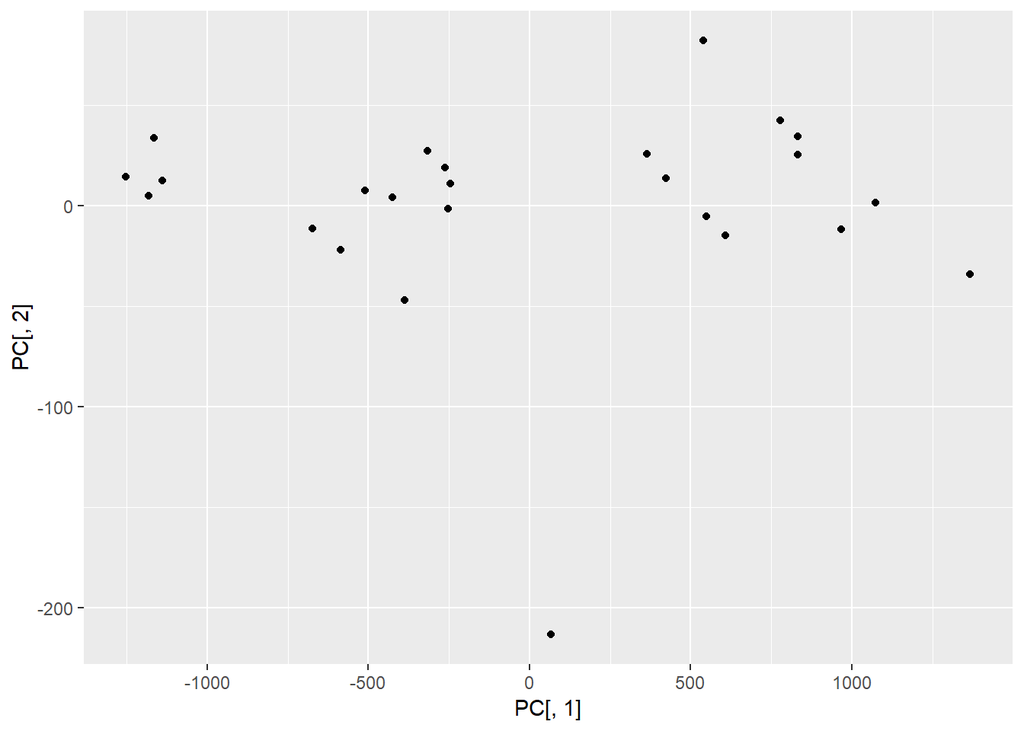

```r
PC <- as.data.frame(data.matrix(Center_auto) %*% Eigen_vector_auto)

ggplot(PC, aes(PC[,1], PC[,2])) + geom_point(aes(PC[,1], PC[,2]))
```

```r
#+ geom_text(aes(label=Auto_data_names[1:8]), nudge_x = -2.5, nudge_y = 400)
```

Step 5. Find out which principal components explain the variance in the data.

```r
#for each component, take the cumulative sum of eigen values up to that point and and divide by the total sum of eigen values
round(cumsum(Eigen_value_auto)/sum(Eigen_value_auto) * 100, digits = 2)
```

```
## [1]  99.52  99.95 100.00 100.00 100.00 100.00 100.00 100.00
```

### R function

Now that we know how PCA works, lets use the R funtion prcomp.

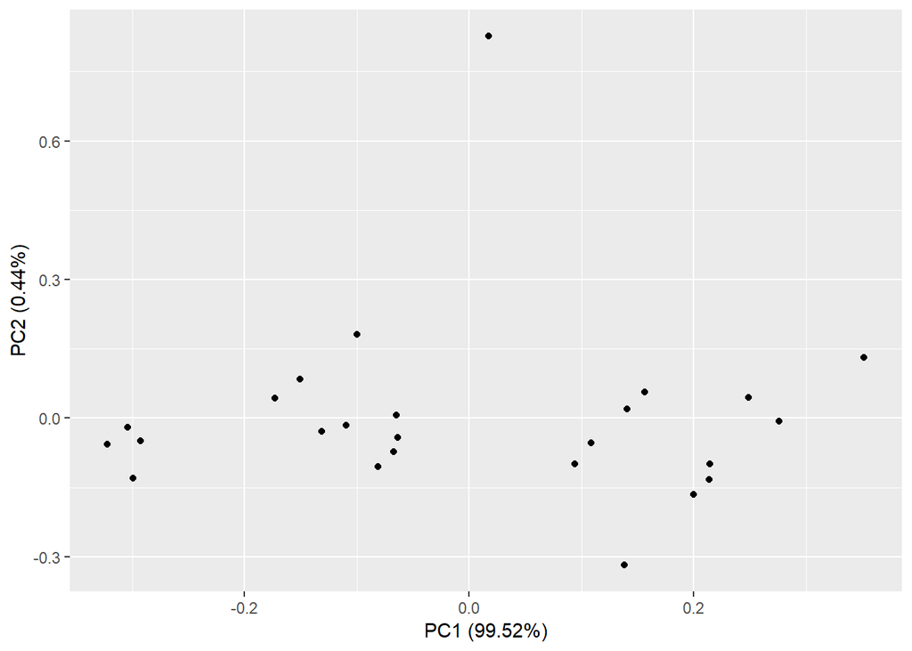

```r
help("prcomp")
autoplot(prcomp(Auto_data_clust_pca))
```

## Independent Component Analysis (ICA)

ICA is an algorithm that finds components that are independent, subcomponents of the data.

Step 1. Whiten the data by projecting the data onto the eigen vectors (PCA).

Step 2. Solve the X=AS equation by maximizing non-gaussianty in the variables(components) in S.

This results in a matrix S with components that are independent from each other.

We will use the fastICA algorithm.

First we will go backwards. Create a matrix S with the independent components

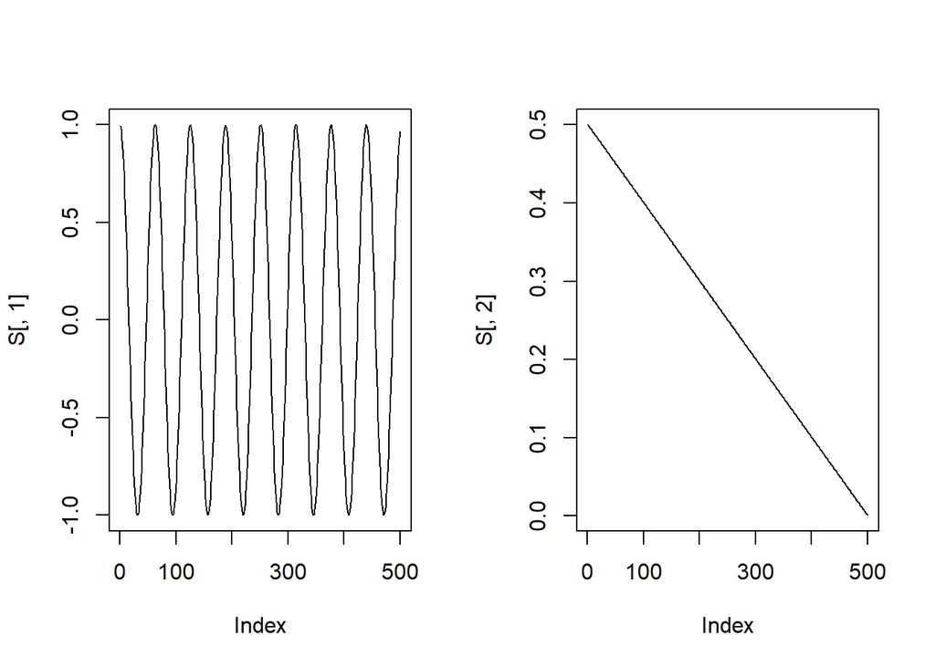

```r
#create two signals
S <- cbind(cos((1:500)/10), ((500:1)/1000))

par(mfcol = c(1, 2))
plot(S[,1], type="l")
plot(S[,2], type="l")
```

Create a mixing matrix A

```r
A <- matrix(c(0.5, 0.7, 0.423, 0.857), 2, 2)
```

Mix S using A

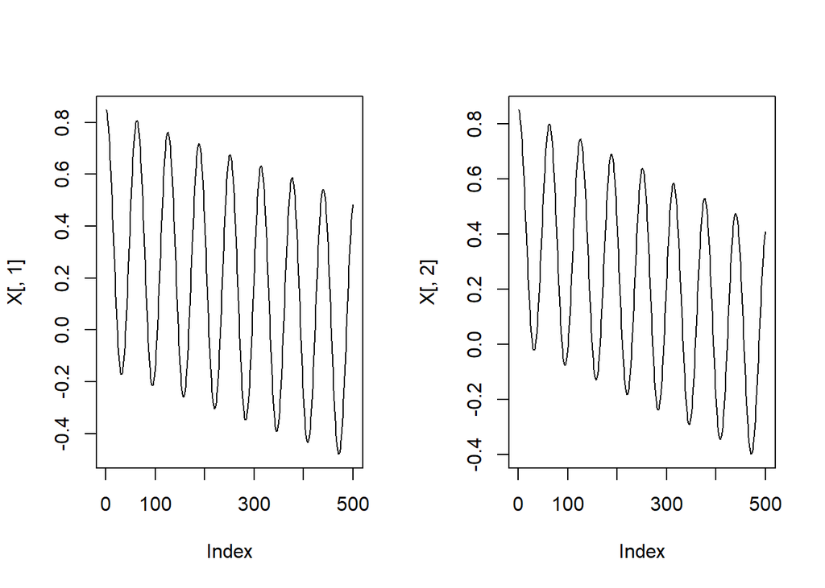

```r
X <- S %*% A
par(mfcol = c(1, 2))
plot(X[,1], type="l")
plot(X[,2], type="l")
```

Unmix using fastICA

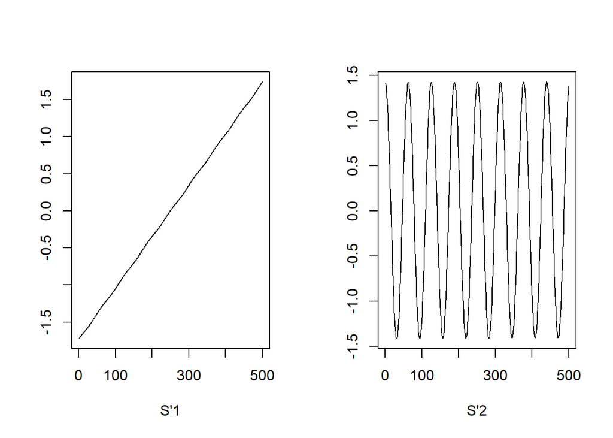

```r
par(mfcol = c(1, 2))
plot(1:500, a$S[,1], type = "l", xlab = "S'1", ylab = "")
plot(1:500, a$S[,2], type = "l", xlab = "S'2", ylab = "")
```

[output not shown]

### ICA on the auto data

plot the independent components as a heatmap

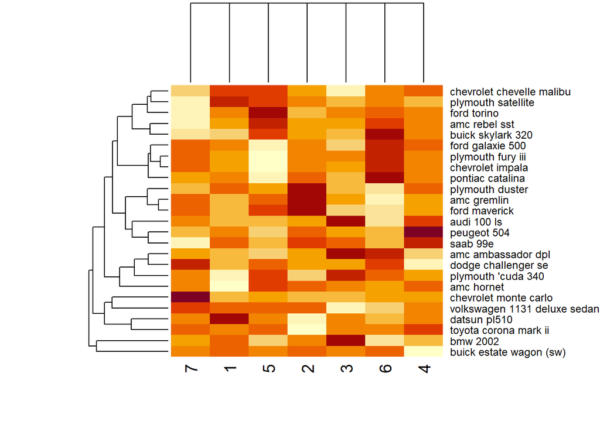

```r
heatmap(a$S)
```

## Homework

```r
data(iris)
```

0. Subset the Iris dataset to only include `Sepal.Length`, `Sepal.Width`, `Petal.Length`, and `Petal.Width`.

```r
df = iris[,-5]
```

1. Write out the Kmeans algorithm by hand, and run two iterations of it.

*The following code creates 3 centroids by creating three new points, created from randomly selecting points within the range of each factor. It then calculates the distance of each point to that centroid and assigns the points to centroids forming three clusters. It then calculates the mean of each cluster and uses them as the new values for the 4 factors (thereby generating 3 new points to act as centroids) and recalculates the distance then reassigns the points*

*While running this code a few times, a problem arose in that, in the initial assigment of cluster points, it can randomly assign points such that only two clusters form because the third is too far away. This would cause the code to break because it acts under the assumption of three clusters. Similarly, it may choose points that lead to heavy imbalances that lead to only two clusters in the second iteration.*

*This is not a problem isolated to my code as it is a common issue for Kmeans due to the random assignment of the initial centroids. This issue is usually resolved by running K-means multiple times.*

*This problem also likely arose due to the fact that two of the species are very similar causing two of the species to cluster together and the third cluster to have no points.*

```r
#Create 3 new random data points to use as initial centroid clusters
centroids = data.frame()
counter=1
for (i in c(151,152,153)){
  for (j in c(1:4)){
    centroids[counter, j] = sample(seq(from = min(df[,j]), to = max(df[,j]), length.out = (max(df[,j])-min(df[,j]))*100), 1)
  }
  counter = counter + 1
}

names(centroids) = names(df)
df = rbind(df, centroids)

#Calculate distance each point is from the 3 centroids
df.dist = as.data.frame(as.matrix(dist(df, method = "euclidean")))
df.dist = tail(df.dist, 3)[,-c(151,152,153)]

#Assign points based on proximity
initassign = c()

for (i in c(1:ncol(df.dist))){
  if (df.dist[1,i]>df.dist[2,i]){
    if (df.dist[1,i]>df.dist[3,i]){
      initassign[i] = 1
    }
    else{
      initassign[i] = 3
    }
  }else{
    if (df.dist[2,i]>df.dist[3,i]){
      initassign[i] = 2
    }else{
      initassign[i] = 3
    }
  }
}

df = cbind(df[-c(151,152,153),], initassign)

#Assigning three new centroids based on mean of clusters
counter = 1
for (i in c(151:153)){
  for (j in c(1:4)){
    df[i,j] = mean(subset(df, df$initassign == counter)[,j])
  }
  counter = counter + 1
}

#Recalculate distance
df.dist = as.data.frame(as.matrix(dist(df, method = "euclidean")))
df.dist = tail(df.dist, 3)[,-c(151,152,153)]

#Reassign points
initassign = c()

for (i in c(1:ncol(df.dist))){
  if (df.dist[1,i]>df.dist[2,i]){
    if (df.dist[1,i]>df.dist[3,i]){
      initassign[i] = 1
    }
    else{
      initassign[i] = 3
    }
  }else{
    if (df.dist[2,i]>df.dist[3,i]){
      initassign[i] = 2
    }else{
      initassign[i] = 3
    }
  }
}

df = cbind(df[-c(151,152,153),], initassign, iris[,5])

View(df)
```

2. Run PCA on the Iris dataset. Plot a scatter plot of PC1 vs PC2 and include the percent variance those PCs describe.

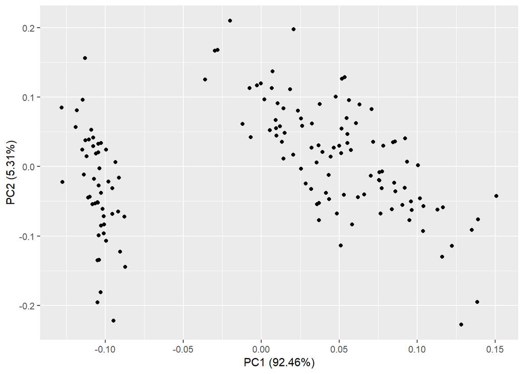

```r
#Creating PCA Model
iris.pca = prcomp(iris[,-5])

#Plotting the Model
autoplot(iris.pca)
```

3. Run ICA on the Iris dataset. Plot the independent components as a heatmap.

```r
#Creating ICA Model
a <- fastICA(iris[,-5], 4, alg.typ = "parallel", fun = "logcosh", alpha = 1,
             method = "R", row.norm = FALSE, maxit = 200,
             tol = 0.0001, verbose = TRUE)
```

[output not shown]

[output not shown]

[output not shown]

[output not shown]

[output not shown]

[output not shown]

[output not shown]

[output not shown]

[output not shown]

[output not shown]

[output not shown]

[output not shown]

[output not shown]

[output not shown]

[output not shown]

[output not shown]

[output not shown]

[output not shown]

[output not shown]

[output not shown]

[output not shown]

[output not shown]

[output not shown]

[output not shown]

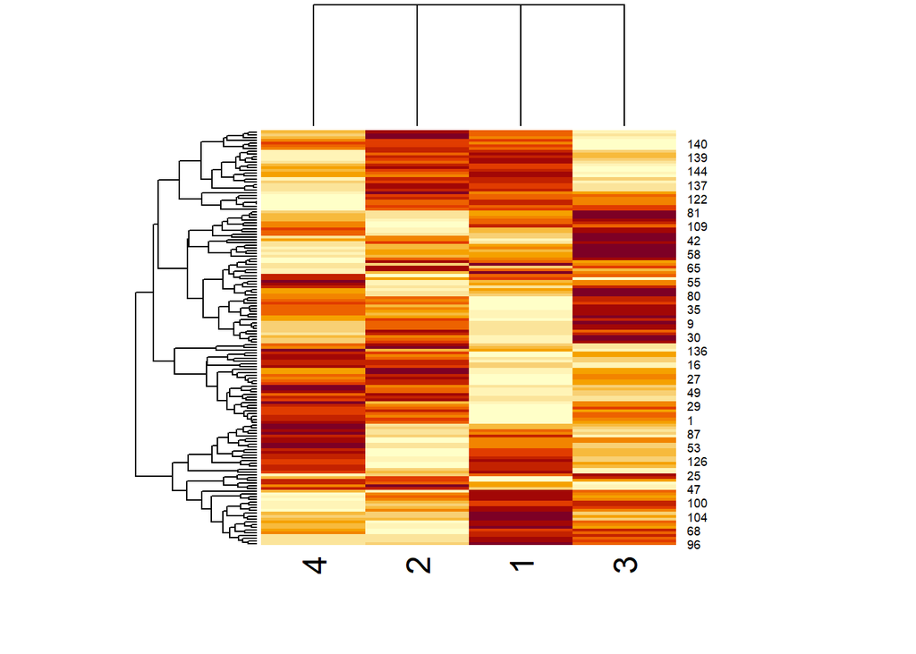

```r
#Creating heatmap of components
heatmap(a$S)
```

4. Use Kmeans to cluster the Iris data.
- Use the silhouette function in the cluster package to find the optimal number of clusters for kmeans for the iris dataset. Then cluster using kmeans clustering. Does the data cluster by species?
- Using this clustering, color the PCA plot according to the clusters.

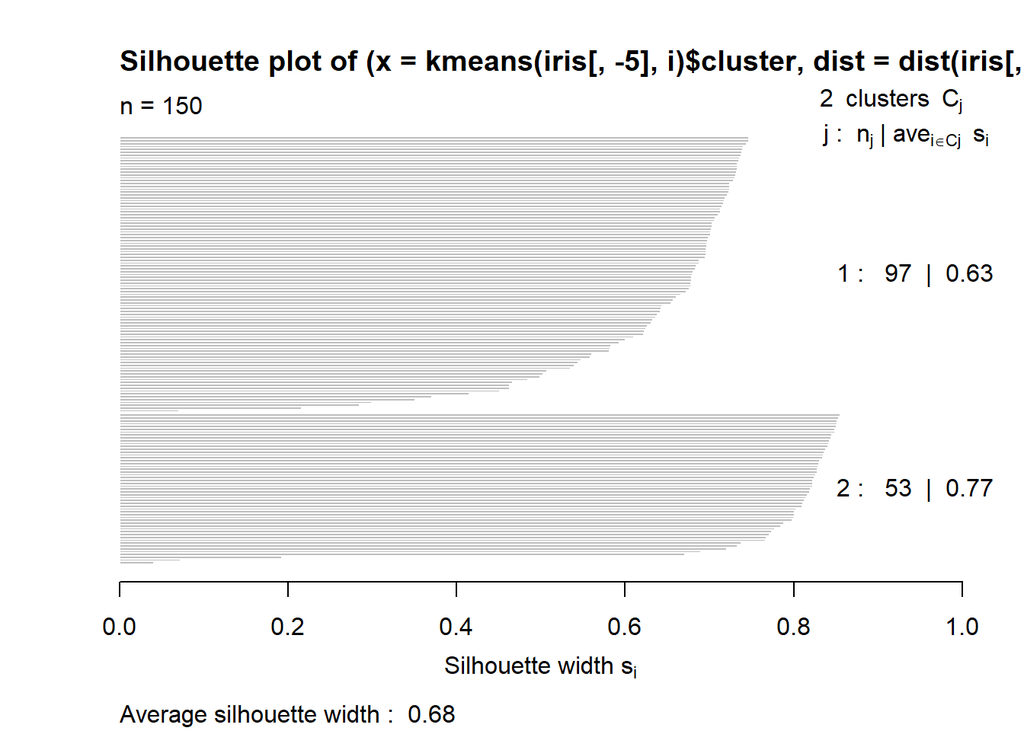

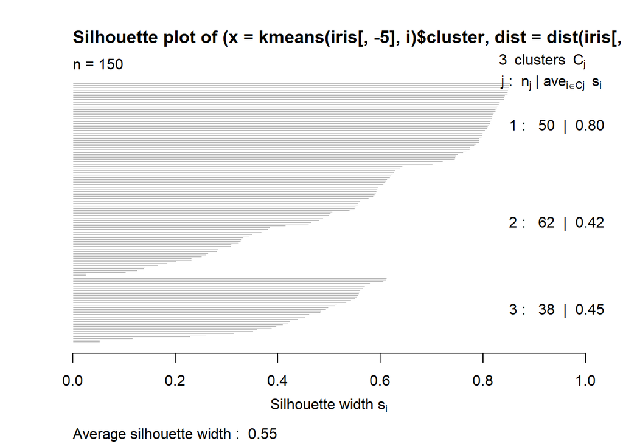

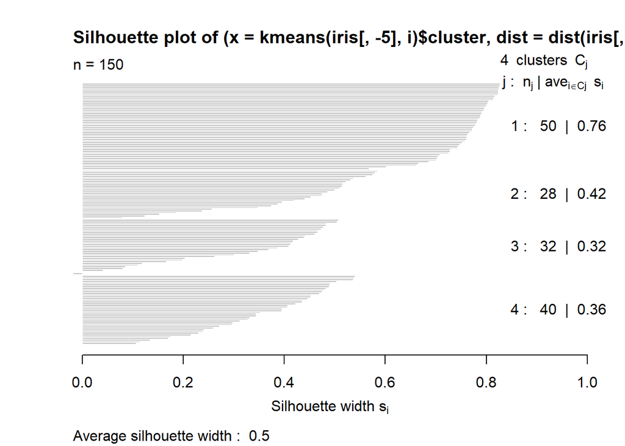

```r
library(cluster)

#Trying 2,3, and 4 clusters
for (i in c(2:4)){
  plot(silhouette(kmeans(iris[,-5], i)$cluster, dist(iris[,-5])))
}
```